# Capstone Milestone Report: Exploratory Analysis

yogarjun77

June 13, 2016

## **1) Introduction**

This analysis only utilizes the US English dataset to demonstrate the capability to build a predictive text model.

The files were downloaded from data source https://d396qusza40orc.cloudfront.net/dsscapstone/dataset/Coursera- SwiftKey.zip and unzipped into a selected folder.

This document only highlights the key points. The full script can be seen at https://github.com/yogarjun77/Data-Science-Capstone

3 huge sources of data are further analyzed in the next steps. They represent 3 writing styles  
+ blogs: informal, casual styles  
+ news: formal, informative  
+ twitter: brief, abbreviated, emojis

First, the necessary libraries are loaded.

```r
library(tm)
library(ggplot2)
library(stringi)
setwd("~/R/final/en_US")
set.seed(521)
```

```r
#load files

con <- file("en_US.blogs.txt", "r", blocking = FALSE)
blogs <- readLines(con)
close(con)

con <- file("en_US.news.txt", "r", blocking = FALSE)
news <- readLines(con)
cat(" def\n", file = "en_US.news.txt", append = TRUE)
news <- readLines(con) # gets both
close(con)

con <- file("en_US.twitter.txt", "r", blocking = FALSE)
twitter <- readLines(con)
close(con)
```

Summary of the extracted files:

```
##             Blogs      News       Twitter
## File Size   "248.5 Mb" "248.5 Mb" "248.5 Mb"
## Words Count "37865888" "23646640" "30578891"
## Rows Count  "899288"   "689014"   "2360148"
```

## **2) Sampling data**

Each dataset has a huge number of lines. Due to limitations in computation power and time, binomial sampling is performed to randomly extract 10% of total lines for use in this analysis.

```r
#sample set creation
blogsample <- rbinom(length(blogs), 1, 0.1)
newssample <- rbinom(length(news), 1, 0.1)
twittersample <- rbinom(length(twitter), 1, 0.1)


blogs <- blogs[blogsample==1]
news <- news[newssample ==1]
twitter <-twitter[twittersample==1]
```

Summary of file samples:

```
##             Blogs     News      Twitter
## File Size   "24.9 Mb" "24.9 Mb" "24.9 Mb"
## Words Count "3797137" "2345976" "3061102"
## Rows Count  "89618"   "68281"   "236103"
```

## **3) Creating a clean corpus**

A corpus is a collection of text document that can be used as the reference source for data mining. Here we attempt to create a clean and usable file combining the input from news, blogs and twitter samples.

```r
#Replace special characters formed due to format conversion issues

specialcharacter <- c("Ã¢â¬Å", "Ã¢â¬Ë", "Ã¢â¬â¢", "Ã¢â¬â", "Ã¢â¬â", "Ã¢â¬Â¢", "Ã¢â¬Â¦", "Ã¢â¬")
translation <- c("â", "â" ,"â", "â", "â", "-", "â¦", "â")

for(i in 1:length(specialcharacter)){
       blogs <- gsub(specialcharacter[i], translation[i], blogs)
 }

for(i in 1:length(specialcharacter)){
       news<- gsub(specialcharacter[i], translation[i], news)
   }

for(i in 1:length(specialcharacter)){
       twitter<- gsub(specialcharacter[i], translation[i], twitter)
   }

## Remove emojis
 blogs<- iconv(blogs, 'UTF-8', 'ASCII', "")
twitter<- iconv(twitter, 'UTF-8', 'ASCII', "")
news<- iconv(news, 'UTF-8', 'ASCII', "")

##Create corpus and remove unnecessary variables to free up memory

writeLines(blogs, con = "en_US.blogs2.txt", sep = "\n", useBytes = F)
writeLines(twitter, con = "en_US.twitter2.txt", sep = "\n", useBytes = F)
writeLines(news, con = "en_US.news2.txt", sep = "\n", useBytes = F)

rm(list=ls())

acorpus <- Corpus(DirSource("./",pattern="en_US.blogs2.txt|en_US.twitter2.txt|en_US.news2.txt"))


## Remove profanity and clean up the corpus

profanitylist <- readLines("profanity-list.txt") # Data for this list was retrieved from https://gist.github.com/jamiew/1112488

acorpus <- tm_map(acorpus, removeWords, profanitylist)
acorpus <- tm_map(acorpus, content_transformer(tolower))
acorpus <- tm_map(acorpus, removeNumbers)
acorpus <- tm_map(acorpus, removePunctuation)
acorpus <- tm_map(acorpus, stripWhitespace)
```

## **4) Ngrams compilation - 1 to 4 most frequent word combinations**

In this section, we build a list of Ngrams (word combinations- single up to 4 words) and sort them out based on frequency of occurence. This will be used in the upcoming prediction model building.

```r
options( java.parameters = "-Xmx4g" )#to assign up to 4GB RAM for java
library(RWeka)

Tokenizer <- function(x) NGramTokenizer(x, Weka_control(min = 1, max = 1))
onedtm <- DocumentTermMatrix(acorpus, control = list(tokenize = Tokenizer))

BigramTokenizer <- function(x) NGramTokenizer(x, Weka_control(min = 2, max = 2))
twodtm <- DocumentTermMatrix(acorpus, control = list(tokenize = BigramTokenizer))


TrigramTokenizer <- function(x) NGramTokenizer(x, Weka_control(min = 3, max = 3))
threedtm <- DocumentTermMatrix(acorpus, control = list(tokenize = TrigramTokenizer))


QuadgramTokenizer <- function(x) NGramTokenizer(x, Weka_control(min = 4, max = 4))
fourdtm <- DocumentTermMatrix(acorpus, control = list(tokenize =QuadgramTokenizer))
rm(acorpus)
```

## **5) Visualization of frequent word list**

First, create a sorted frequency table of Ngrams

```r
tm_freq <- sort(colSums(as.matrix(onedtm)), decreasing=TRUE)
tm_wordfreq <- data.frame(word=names(tm_freq), freq=tm_freq)
tm_wordfreq$word = factor(tm_wordfreq$word, levels = tm_wordfreq$word[order(-tm_wordfreq$freq)])
```

Repeat for 2, 3 and 4 Ngrams (code not shown)

Create a plot function to visualize

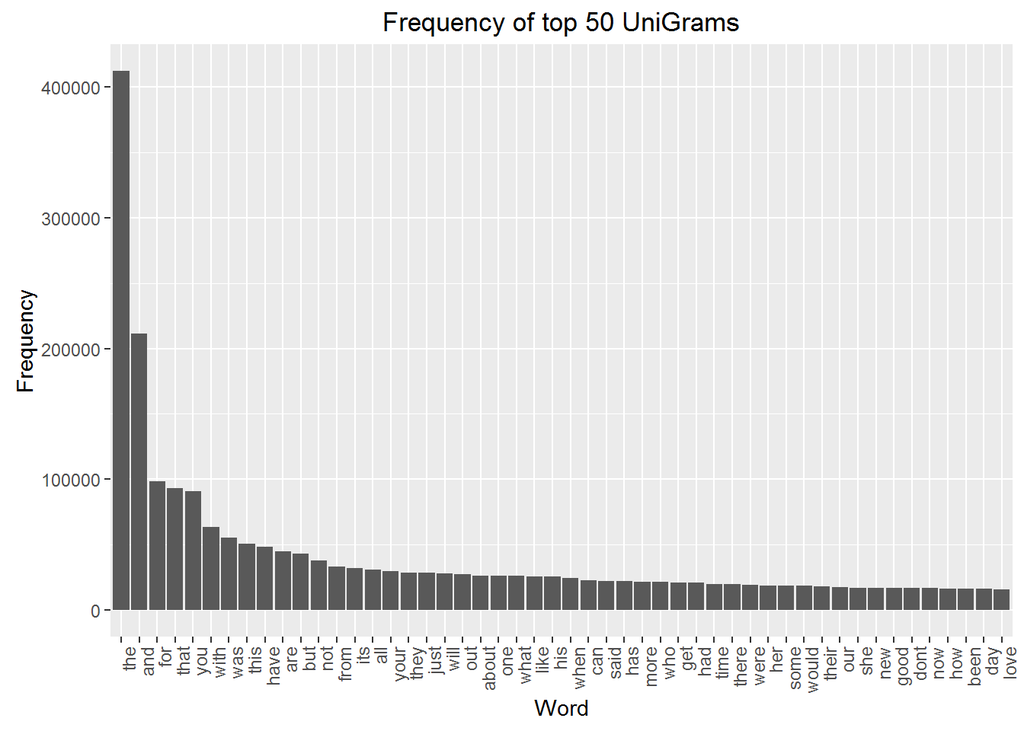

```r
#Plot for unigrams
ggplot(head(tm_wordfreq, 50), aes(word, freq))+geom_bar(stat = "identity") + labs(title = "Frequency of top 50 UniGrams")+ xlab("Word") + ylab("Frequency") + theme(axis.text.x = element_text(angle = 90, hjust = 1)) + scale_y_continuous(labels =function(tm_wordfreq){format(tm_wordfreq, scientific=FALSE)})
```

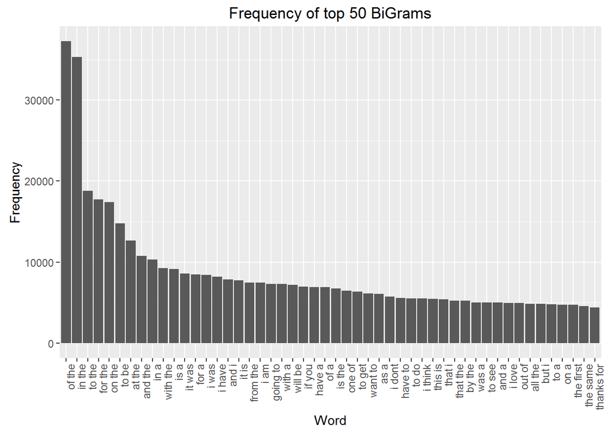

```r
#Plot for bigrams
ggplot(head(tm_2wordfreq, 50), aes(word, freq))+geom_bar(stat = "identity") + labs(title = "Frequency of top 50 BiGrams")+ xlab("Word") + ylab("Frequency") + theme(axis.text.x = element_text(angle = 90, hjust = 1)) + scale_y_continuous(labels =function(tm_2wordfreq){format(tm_2wordfreq, scientific=FALSE)})
```

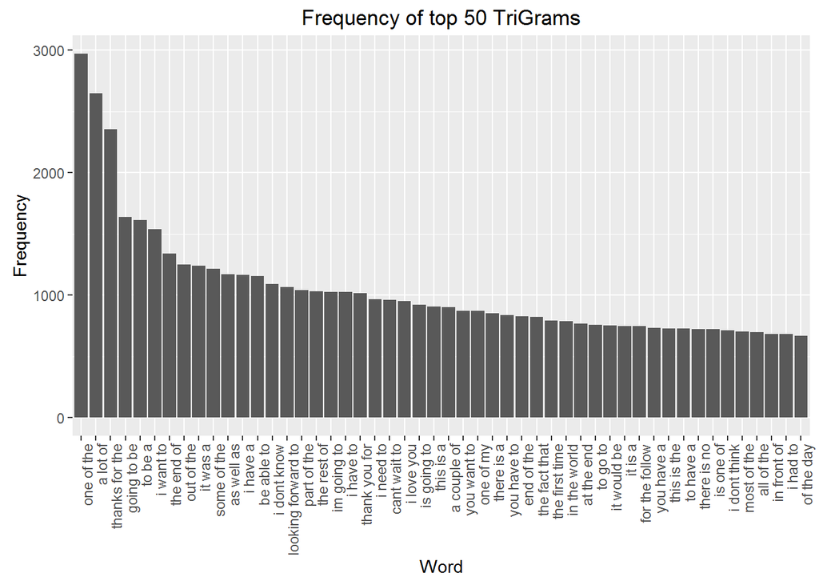

```r
#Plot for trigrams
ggplot(head(tm_3wordfreq, 50), aes(word, freq))+geom_bar(stat = "identity") + labs(title = "Frequency of top 50 TriGrams")+ xlab("Word") + ylab("Frequency") + theme(axis.text.x = element_text(angle = 90, hjust = 1)) + scale_y_continuous(labels =function(tm_3wordfreq){format(tm_3wordfreq, scientific=FALSE)})
```

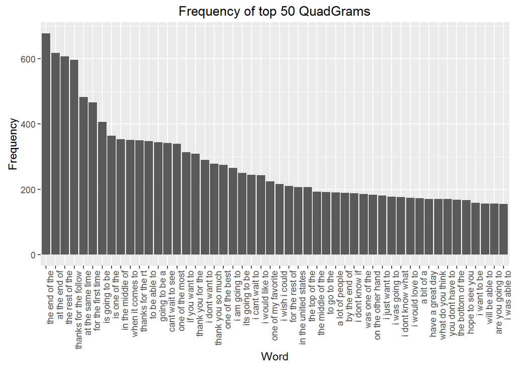

```r
#Plot for quadgrams
ggplot(head(tm_4wordfreq, 50), aes(word, freq))+geom_bar(stat = "identity") + labs(title = "Frequency of top 50 QuadGrams")+ xlab("Word") + ylab("Frequency") + theme(axis.text.x = element_text(angle = 90, hjust = 1)) + scale_y_continuous(labels =function(tm_4wordfreq){format(tm_4wordfreq, scientific=FALSE)})
```

## **Conclusion**

Data show a multitude of NGrams possibilities that are skewed around the highest 5 to 10 combination.

A better understanding of the data, and effective cleaning has been achieved. The basic exploration and identification has been completed. The list of common words and phrases that are obtained will be used for the next stage of predictive text model building.